# Clustering Mall Customers

**Importing The Required Libraries & Packages**

```python
import numpy as np
import pandas as pd
import matplotlib.pyplot as plt
import os
import seaborn as sns
%matplotlib inline
from sklearn.cluster import KMeans
import scipy.cluster.hierarchy as sch
from sklearn.cluster import AgglomerativeClustering
import warnings
warnings.filterwarnings('ignore')
```

**Changing The Default Working Directory Path & Reading The Dataset Using Pandas Command**

```python
os.chdir('D:\\bala\\study things\\data science\\Batch 74 Day 18\\Batch 74 Day 18\\')
df = pd.read_csv('Mall_Customers.csv')
```

**Automated Exploratory Data Analysis (EDA) with ydata_profiling(pandas_profiling)**

```python
import ydata_profiling as pf
display(pf.ProfileReport(df))
```

[interactive chart not shown]

**Checking the Null values of all the Columns in the dataset**

```python
df.isnull().sum()
```

```
CustomerID                0
Gender                    0
Age                       0
Annual Income (k$)        0
Spending Score (1-100)    0
dtype: int64
```

**Assigning the independent variable since it a Clustering Model there is no dependent variable**

```python
x = df.iloc[:,3:].values
```

**Finding the WCSS(Within Cluster Sum of Squares) values using KMeans Clustering**

```python
wcss = []
for i in range(2,11):
    kmeans = KMeans(n_clusters=i,init='k-means++')
    kmeans.fit(x)
    wcss.append(kmeans.inertia_)
display(wcss)
```

```
[181363.59595959593,
 106348.37306211118,
 73679.78903948836,
 44448.45544793371,
 37233.81451071001,
 31280.903845940935,
 25030.38309852033,
 22758.45764164105,
 19787.670554966855]
```

```python
from matplotlib.pylab import rcParams
rcParams['figure.figsize']=(20,10)
```

**Plotting the Line Graph with WCSS Values to get the exact ideal number of clusters to be created using KMeans Clustering Algorithm and saving the PNG file**

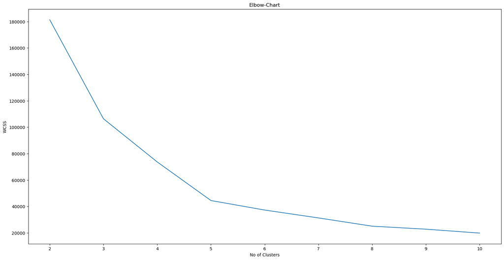

```python
plt.plot(range(2,11),wcss)
plt.title('Elbow-Chart')
plt.xlabel('No of Clusters')
plt.ylabel('WCSS')
plt.savefig('Elbow Method Grapg.png')
plt.show()
```

**Fitting the KMeans Clustering model with ideal number of clusters found from Elbow Method Graph and getting the dataset belonging to the cluster**

```python
kmeans = KMeans(n_clusters=5,init='k-means++')
kmeans.fit(x)
y_kmeans = kmeans.labels_
display(y_kmeans)
```

```
array([0, 3, 0, 3, 0, 3, 0, 3, 0, 3, 0, 3, 0, 3, 0, 3, 0, 3, 0, 3, 0, 3,
       0, 3, 0, 3, 0, 3, 0, 3, 0, 3, 0, 3, 0, 3, 0, 3, 0, 3, 0, 3, 0, 1,
       0, 3, 1, 1, 1, 1, 1, 1, 1, 1, 1, 1, 1, 1, 1, 1, 1, 1, 1, 1, 1, 1,
       1, 1, 1, 1, 1, 1, 1, 1, 1, 1, 1, 1, 1, 1, 1, 1, 1, 1, 1, 1, 1, 1,
       1, 1, 1, 1, 1, 1, 1, 1, 1, 1, 1, 1, 1, 1, 1, 1, 1, 1, 1, 1, 1, 1,
       1, 1, 1, 1, 1, 1, 1, 1, 1, 1, 1, 1, 1, 4, 2, 4, 1, 4, 2, 4, 2, 4,
       1, 4, 2, 4, 2, 4, 2, 4, 2, 4, 1, 4, 2, 4, 2, 4, 2, 4, 2, 4, 2, 4,
       2, 4, 2, 4, 2, 4, 2, 4, 2, 4, 2, 4, 2, 4, 2, 4, 2, 4, 2, 4, 2, 4,
       2, 4, 2, 4, 2, 4, 2, 4, 2, 4, 2, 4, 2, 4, 2, 4, 2, 4, 2, 4, 2, 4,
       2, 4])
```

**Plotting the Scatter Plot Graph with the independent variable and the Cluster which it belongs and saving the PNG file**

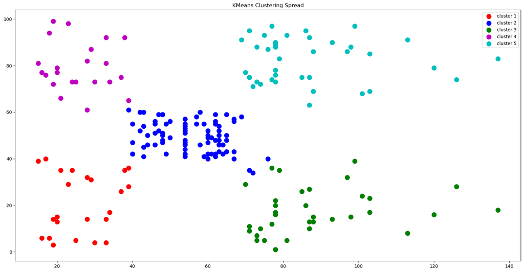

```python
plt.scatter(x[y_kmeans==0,0],x[y_kmeans==0,1],s=100,c='r',label='cluster 1')
plt.scatter(x[y_kmeans==1,0],x[y_kmeans==1,1],s=100,c='b',label='cluster 2')
plt.scatter(x[y_kmeans==2,0],x[y_kmeans==2,1],s=100,c='g',label='cluster 3')
plt.scatter(x[y_kmeans==3,0],x[y_kmeans==3,1],s=100,c='m',label='cluster 4')
plt.scatter(x[y_kmeans==4,0],x[y_kmeans==4,1],s=100,c='c',label='cluster 5')
plt.legend()
plt.title('KMeans Clustering Spread')
plt.savefig('KMeans Clustering Spread Graph.png')
plt.show()
```

**Merging the Cluster Number and adding the seperate column for it with Original dataset and displaying the resulting dataset**

```python
result = pd.concat([df,pd.DataFrame(y_kmeans,columns=['ClusterNumber'])],axis=1)
result
```

|  | CustomerID | Gender | Age | Annual Income (k$) | Spending Score (1-100) | ClusterNumber |
| --- | --- | --- | --- | --- | --- | --- |
| 0 | 1 | Male | 19 | 15 | 39 | 0 |
| 1 | 2 | Male | 21 | 15 | 81 | 3 |
| 2 | 3 | Female | 20 | 16 | 6 | 0 |
| 3 | 4 | Female | 23 | 16 | 77 | 3 |
| 4 | 5 | Female | 31 | 17 | 40 | 0 |
| ... | ... | ... | ... | ... | ... | ... |
| 195 | 196 | Female | 35 | 120 | 79 | 4 |
| 196 | 197 | Female | 45 | 126 | 28 | 2 |
| 197 | 198 | Male | 32 | 126 | 74 | 4 |
| 198 | 199 | Male | 32 | 137 | 18 | 2 |
| 199 | 200 | Male | 30 | 137 | 83 | 4 |

200 rows × 6 columns

**grouping by the cluster number to see the number of values in each clusters**

```python
result.groupby('ClusterNumber').size()
```

```
ClusterNumber
0    23
1    81
2    35
3    22
4    39
dtype: int64
```

**grouping by the Cluster Number with respect to Annual Income and Spending Score to get the Minimum and Maximum value of Annual Income and Spending Score for each clusters.**

```python
result.groupby('ClusterNumber').agg({'Annual Income (k$)':[np.min,np.max],'Spending Score (1-100)':[np.min,np.max]})
```

| ClusterNumber | Annual Income (k$) amin | Annual Income (k$) amax | Spending Score (1-100) amin | Spending Score (1-100) amax |
| --- | --- | --- | --- | --- |
| 0 | 15 | 39 | 3 | 40 |
| 1 | 39 | 76 | 34 | 61 |
| 2 | 70 | 137 | 1 | 39 |
| 3 | 15 | 39 | 61 | 99 |
| 4 | 69 | 137 | 63 | 97 |

**Plotting the Dendogram Graph using ward method to find out the exact ideal number of cluster to be created using Agglomerative Clustering Model with ward Linkage and saving the PNG file**

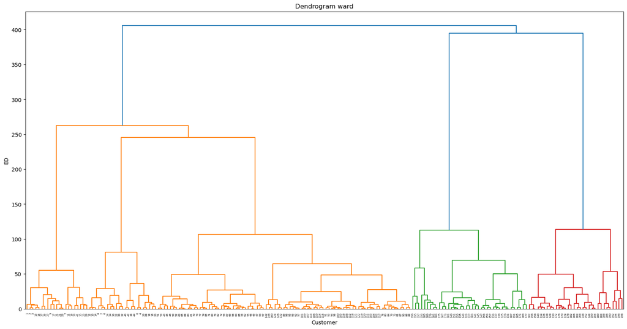

```python
dend = sch.dendrogram(sch.linkage(x,method='ward'))
plt.title('Dendrogram ward')
plt.xlabel('Customer')
plt.ylabel('ED')
plt.savefig('Dendogram Ward.png')
plt.show()
```

**Fitting the Agglomerative Clustering model with ideal number of clusters found from Dendogram using ward method and predicting the dataset belonging to the cluster.**

```python
hc = AgglomerativeClustering(n_clusters=5,linkage='ward')
y_hc = hc.fit_predict(x)
```

**Plotting the Scatter Plot Graph with the independent variable and the Cluster which it belongs and saving the PNG file**

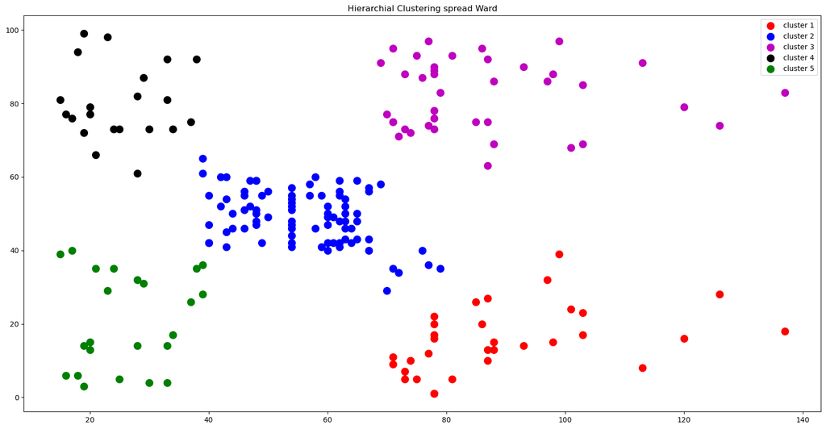

```python
plt.scatter(x[y_hc==0,0],x[y_hc==0,1],s=100,c='r',label='cluster 1')
plt.scatter(x[y_hc==1,0],x[y_hc==1,1],s=100,c='b',label='cluster 2')
plt.scatter(x[y_hc==2,0],x[y_hc==2,1],s=100,c='m',label='cluster 3')
plt.scatter(x[y_hc==3,0],x[y_hc==3,1],s=100,c='k',label='cluster 4')
plt.scatter(x[y_hc==4,0],x[y_hc==4,1],s=100,c='g',label='cluster 5')
plt.legend()
plt.title('Hierarchial Clustering spread Ward')
plt.savefig('Hierarchial Clustering spread Ward.png')
plt.show()
```

**Merging the Cluster Number and adding the seperate column for it with Original dataset and displaying the resulting dataset**

```python
result_hc = pd.concat([df,pd.DataFrame(y_hc,columns=['ClusterNumber'])],axis=1)
result_hc
```

|  | CustomerID | Gender | Age | Annual Income (k$) | Spending Score (1-100) | ClusterNumber |
| --- | --- | --- | --- | --- | --- | --- |
| 0 | 1 | Male | 19 | 15 | 39 | 4 |
| 1 | 2 | Male | 21 | 15 | 81 | 3 |
| 2 | 3 | Female | 20 | 16 | 6 | 4 |
| 3 | 4 | Female | 23 | 16 | 77 | 3 |
| 4 | 5 | Female | 31 | 17 | 40 | 4 |
| ... | ... | ... | ... | ... | ... | ... |
| 195 | 196 | Female | 35 | 120 | 79 | 2 |
| 196 | 197 | Female | 45 | 126 | 28 | 0 |
| 197 | 198 | Male | 32 | 126 | 74 | 2 |
| 198 | 199 | Male | 32 | 137 | 18 | 0 |
| 199 | 200 | Male | 30 | 137 | 83 | 2 |

200 rows × 6 columns

**Grouping by the Cluster Number with respect to Annual Income and Spending Score to get the Minimum,Maximum value of Annual Income and Spending Score and the number of values in each clusters.**

```python
result_hc.groupby('ClusterNumber').agg({'Annual Income (k$)':[np.min,np.max],'Spending Score (1-100)':[np.min,np.max,np.size]})
```

| ClusterNumber | Annual Income (k$) amin | Annual Income (k$) amax | Spending Score (1-100) amin | Spending Score (1-100) amax | Spending Score (1-100) size |
| --- | --- | --- | --- | --- | --- |
| 0 | 71 | 137 | 1 | 39 | 32 |
| 1 | 39 | 79 | 29 | 65 | 85 |
| 2 | 69 | 137 | 63 | 97 | 39 |
| 3 | 15 | 38 | 61 | 99 | 21 |
| 4 | 15 | 39 | 3 | 40 | 23 |

**Plotting the Dendogram Graph using single method to find out the exact ideal number of cluster to be created using Agglomerative Clustering Model with single Linkage and saving the PNG file**

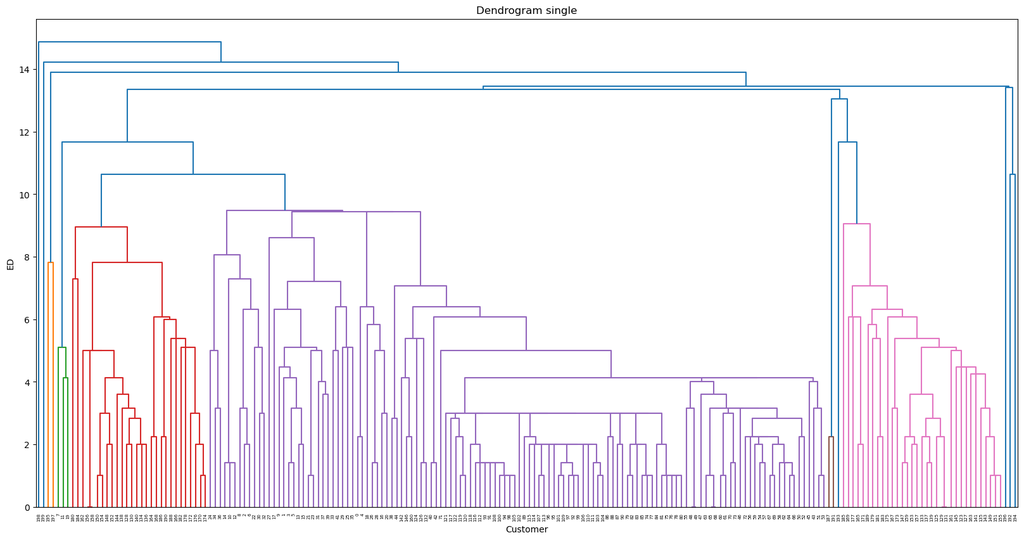

```python
import matplotlib.pyplot as plt
from scipy.cluster import hierarchy as sch
dendrogram = sch.dendrogram(sch.linkage(x, method='single'))

plt.title('Dendrogram single')
plt.xlabel('Customer')
plt.ylabel('ED')
plt.savefig('Dendogram Single.png')
plt.show()
```

**Fitting the Agglomerative Clustering model with ideal number of clusters found from Dendogram using single method and predicting the dataset belonging to the cluster.**

```python
hc1 = AgglomerativeClustering(n_clusters=7,linkage='single')
y_hc1 = hc1.fit_predict(x)
```

**Plotting the Scatter Plot Graph with the independent variable and the Cluster which it belongs and saving the PNG file**

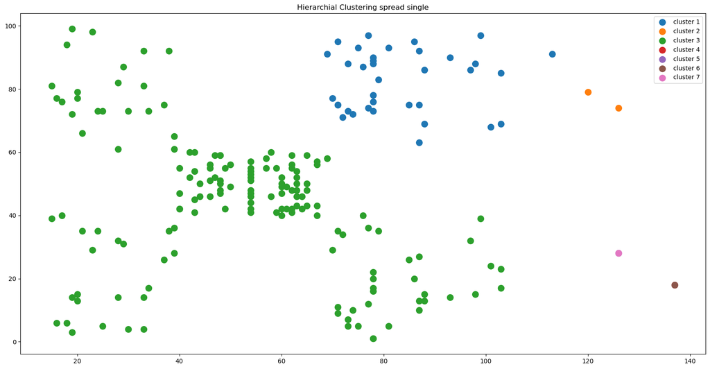

```python
plt.scatter(x[y_hc1==0,0],x[y_hc1==0,1],s=100,label='cluster 1')
plt.scatter(x[y_hc1==1,0],x[y_hc1==1,1],s=100,label='cluster 2')
plt.scatter(x[y_hc1==2,0],x[y_hc1==2,1],s=100,label='cluster 3')
plt.scatter(x[y_hc1==3,0],x[y_hc1==3,1],s=100,label='cluster 4')
plt.scatter(x[y_hc1==4,0],x[y_hc1==4,1],s=100,label='cluster 5')
plt.scatter(x[y_hc1==3,0],x[y_hc1==3,1],s=100,label='cluster 6')
plt.scatter(x[y_hc1==4,0],x[y_hc1==4,1],s=100,label='cluster 7')
plt.legend()
plt.title('Hierarchial Clustering spread single')
plt.savefig('Hierarchial Clustering spread single.png')
plt.show()
```

**Merging the Cluster Number and adding the seperate column for it with Original dataset and displaying the resulting dataset**

```python
result_hc1 = pd.concat([df,pd.DataFrame(y_hc1,columns=['Number of Cluster'])],axis=1)
```

**Grouping by the Cluster Number with respect to Annual Income and Spending Score to get the Minimum,Maximum value of Annual Income and Spending Score and the number of values in each clusters.**

```python
result_hc1.groupby('Number of Cluster').agg({'Annual Income (k$)':[np.min,np.max],'Spending Score (1-100)':[np.min,np.max,np.size]})
```

[output not shown]

**Plotting the Dendogram Graph using complete method to find out the exact ideal number of cluster to be created using Agglomerative Clustering Model with complete Linkage and saving the PNG file**

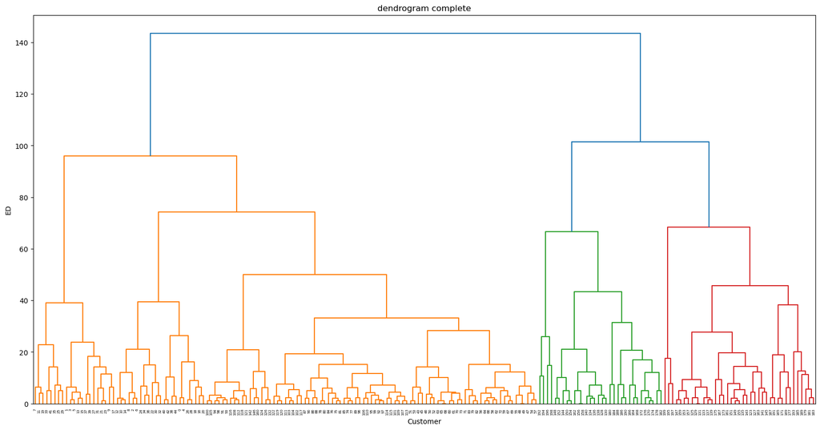

```python
dend = sch.dendrogram(sch.linkage(x,method = 'complete'))
plt.title('dendrogram complete')
plt.xlabel('Customer')
plt.ylabel('ED')
plt.savefig('Dendogram Complete.png')
plt.show()
```

**Fitting the Agglomerative Clustering model with ideal number of clusters found from Dendogram using complete method and predicting the dataset belonging to the cluster.**

```python
hc2 = AgglomerativeClustering(n_clusters=5,linkage='complete')
y_hc2 = hc2.fit_predict(x)
```

**Plotting the Scatter Plot Graph with the independent variable and the Cluster which it belongs and saving the PNG file**

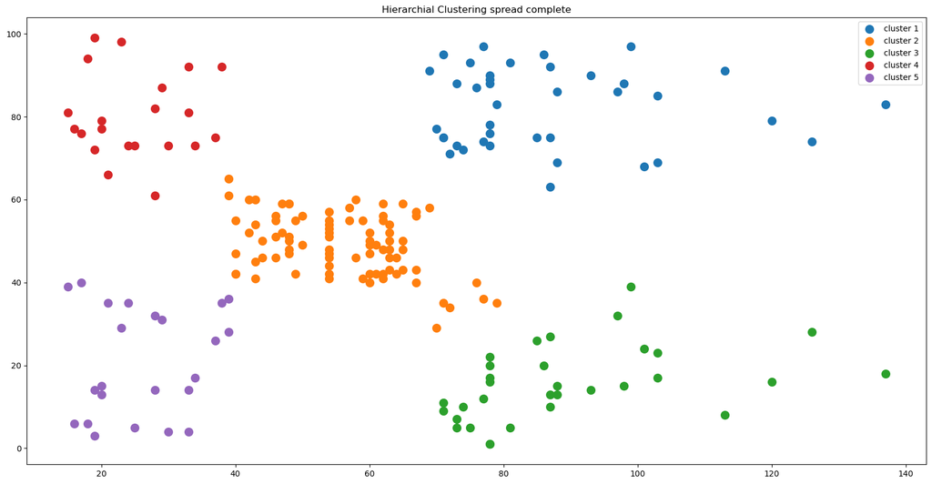

```python
plt.scatter(x[y_hc2==0,0],x[y_hc2==0,1],s=100,label='cluster 1')
plt.scatter(x[y_hc2==1,0],x[y_hc2==1,1],s=100,label='cluster 2')
plt.scatter(x[y_hc2==2,0],x[y_hc2==2,1],s=100,label='cluster 3')
plt.scatter(x[y_hc2==3,0],x[y_hc2==3,1],s=100,label='cluster 4')
plt.scatter(x[y_hc2==4,0],x[y_hc2==4,1],s=100,label='cluster 5')
plt.legend()
plt.title('Hierarchial Clustering spread complete')
plt.savefig('Hierarchial Clustering spread complete.png')
plt.show()
```

**Plotting the Dendogram Graph using average method to find out the exact ideal number of cluster to be created using Agglomerative Clustering Model with average linkage and saving the PNG file**

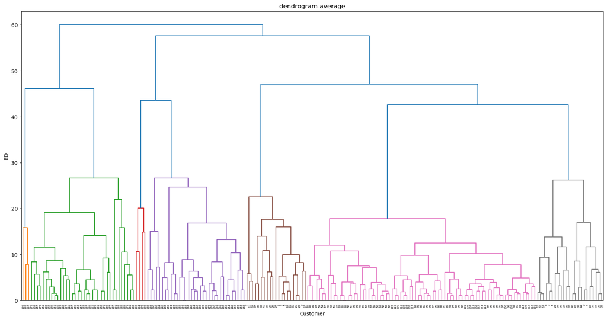

```python
dend = sch.dendrogram(sch.linkage(x,method='average'))
plt.title('dendrogram average')
plt.xlabel('Customer')
plt.ylabel('ED')
plt.savefig('Dendogram Average.png')
plt.show()
```

**Fitting the Agglomerative Clustering model with ideal number of clusters found from Dendogram using average method and predicting the dataset belonging to the cluster.**

```python
hc3 = AgglomerativeClustering(n_clusters=7,linkage='average')
y_hc3 = hc3.fit_predict(x)
```

**Plotting the Scatter Plot Graph with the independent variable and the Cluster which it belongs and saving the PNG file**

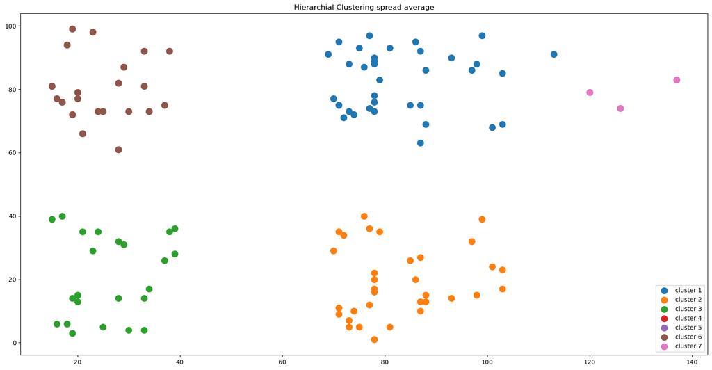

```python
plt.scatter(x[y_hc3==0,0],x[y_hc3==0,1],s=100,label='cluster 1')
plt.scatter(x[y_hc3==1,0],x[y_hc3==1,1],s=100,label='cluster 2')
plt.scatter(x[y_hc3==2,0],x[y_hc3==2,1],s=100,label='cluster 3')
plt.scatter(x[y_hc3==3,0],x[y_hc3==3,1],s=100,label='cluster 4')
plt.scatter(x[y_hc3==4,0],x[y_hc3==4,1],s=100,label='cluster 5')
plt.scatter(x[y_hc3==3,0],x[y_hc3==3,1],s=100,label='cluster 6')
plt.scatter(x[y_hc3==4,0],x[y_hc3==4,1],s=100,label='cluster 7')
plt.legend()
plt.title('Hierarchial Clustering spread average')
plt.savefig('Hierarchial Clustering spread average.png')
plt.show()
```

**Merging the Cluster Number and adding the seperate column for it with Original dataset and displaying the resulting dataset**

```python
result_hc3 = pd.concat([df,pd.DataFrame(y_hc3,columns=['Number of Cluster'])],axis=1)
```

**Grouping by the Cluster Number with respect to Annual Income and Spending Score to get the Minimum,Maximum value of Annual Income and Spending Score and the number of values in each clusters**

```python
result_hc3.groupby('Number of Cluster').agg({'Annual Income (k$)':[np.min,np.max],'Spending Score (1-100)':[np.min,np.max,np.size]})
```

| Number of Cluster | Annual Income (k$) amin | Annual Income (k$) amax | Spending Score (1-100) amin | Spending Score (1-100) amax | Spending Score (1-100) size |
| --- | --- | --- | --- | --- | --- |
| 0 | 69 | 113 | 63 | 97 | 36 |
| 1 | 70 | 103 | 1 | 40 | 34 |
| 2 | 15 | 39 | 3 | 40 | 23 |
| 3 | 15 | 38 | 61 | 99 | 21 |
| 4 | 120 | 137 | 74 | 83 | 3 |
| 5 | 113 | 137 | 8 | 28 | 4 |
| 6 | 39 | 69 | 40 | 65 | 79 |